# Wind Error: inference on distribution

Author

Diego

## Renato’s graphs

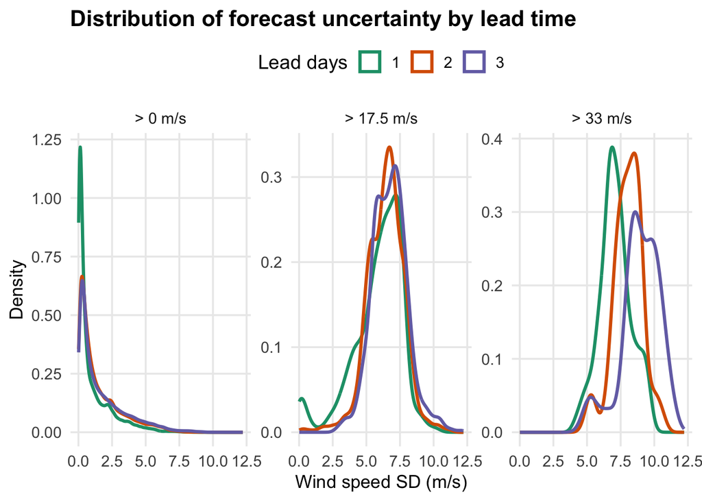

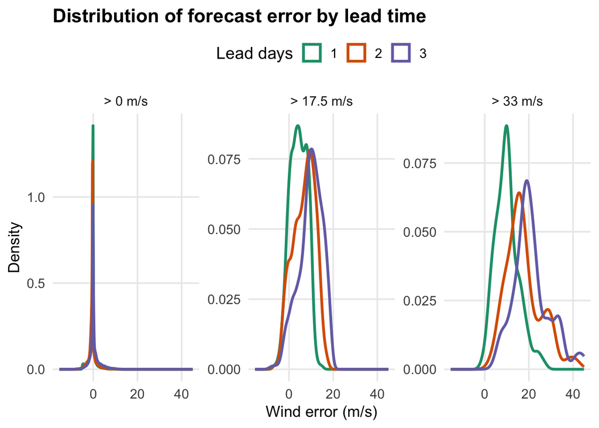

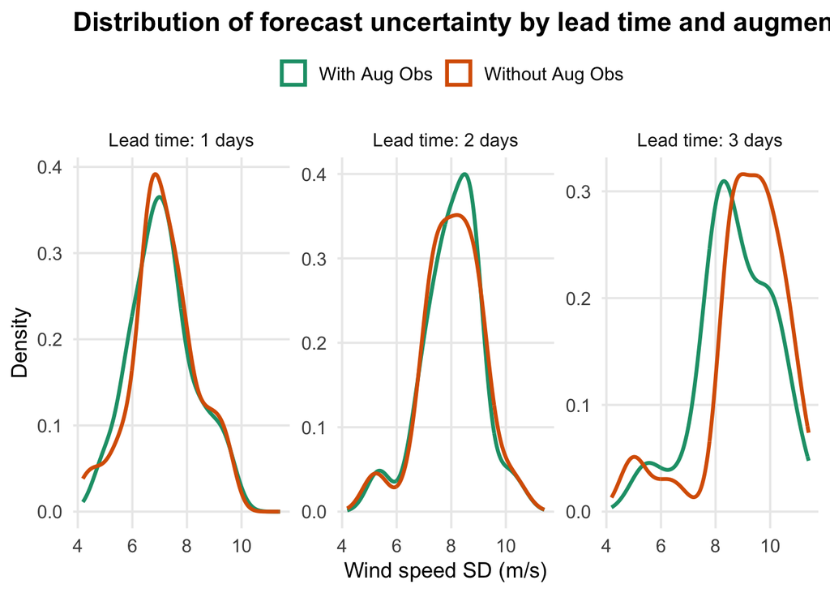

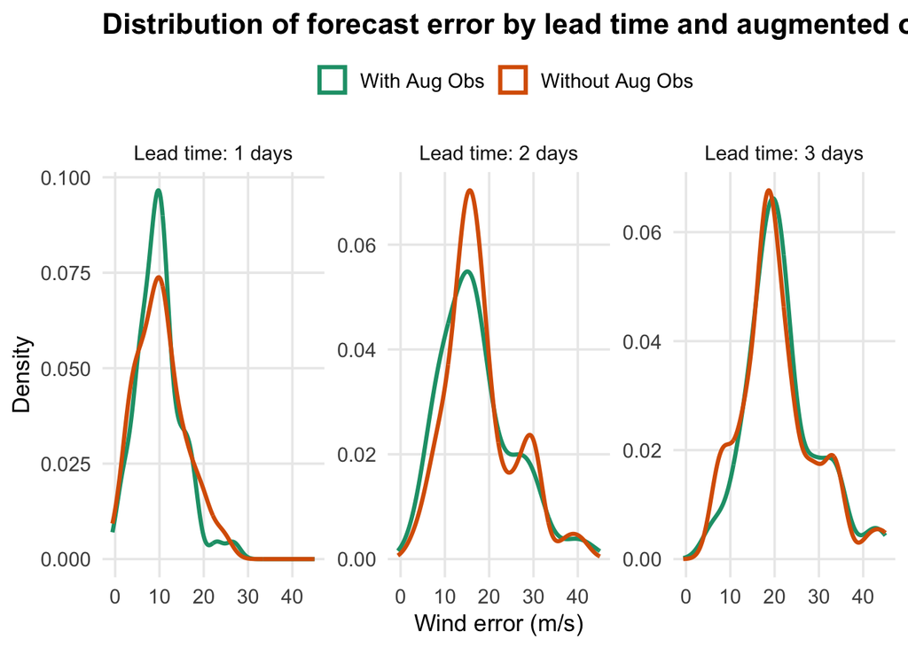

## Inference on distribution

1. Mean effects
2. Unconditional and conditional (on observed wind speed) quantile shifts

**Note: This is all preliminary and, techincally, incorrect. We are looking at moments of means, not of the actual forecast points. The correct way of doing this would be to use all the data points, not errors aggregated by county and lead day.**

### Mean effects

This is similar in spirit to Renato’s regressions. But I am not super convinced that a regression with fixed effect structure makes sense for this analysis. The goal was to control for underlying variation and use augmented observations as an exogenous treatment. But the fundamental problem of causal inference is not an issue for this analysis because we observe both the treated and untreated outcomes! We can literally just take differences in means and possibly segment by lead time and bins of wind speed. But it may also helpful to regress on observed wind speed to assess a mean effect conditional on a continuous variable.

Assemble dataset pairing forecast errors with and without augmented observations

Let’s look at the densities of the reductions.

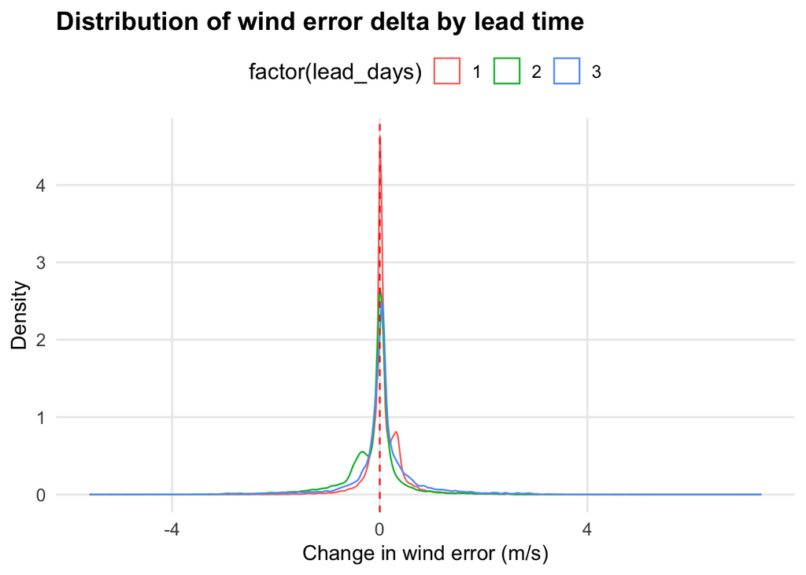

There is a minor location shift, but this doesn’t tell us much. Let’s see the other metrics.

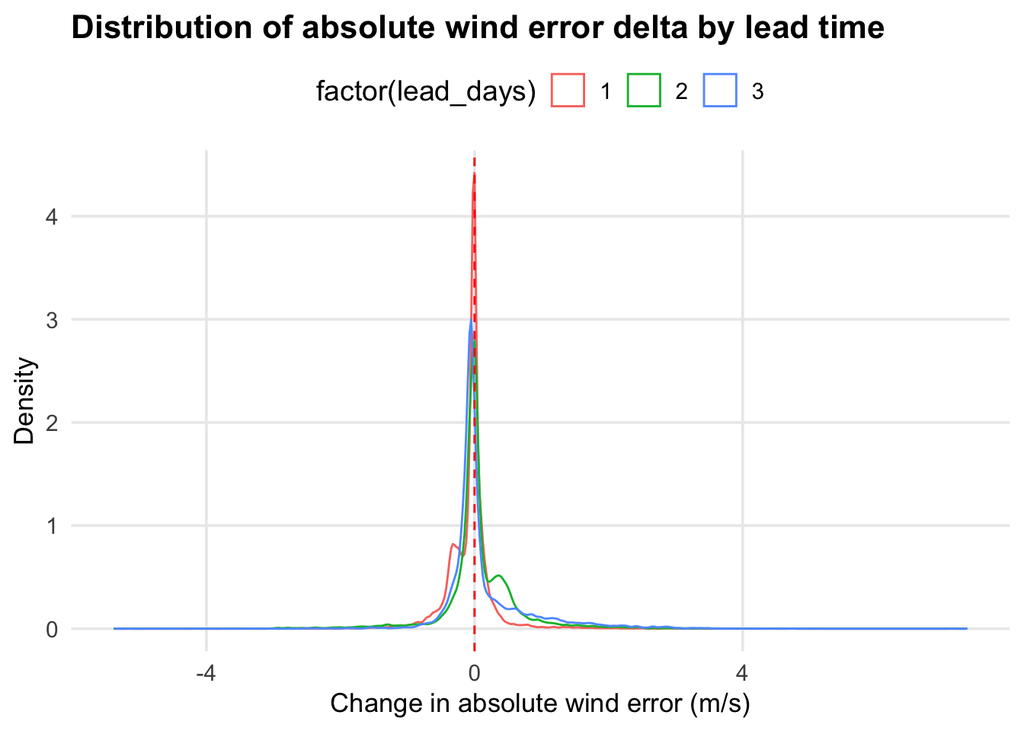

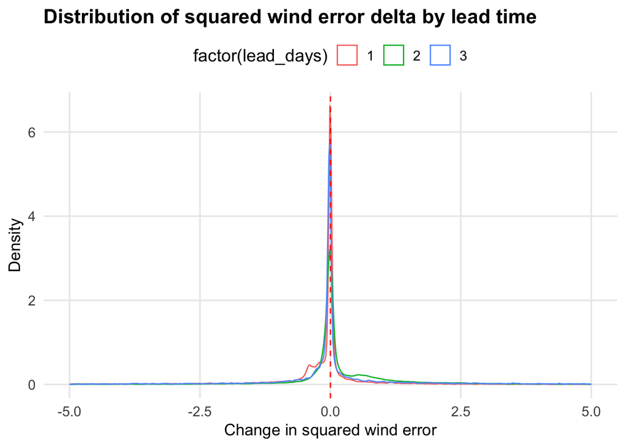

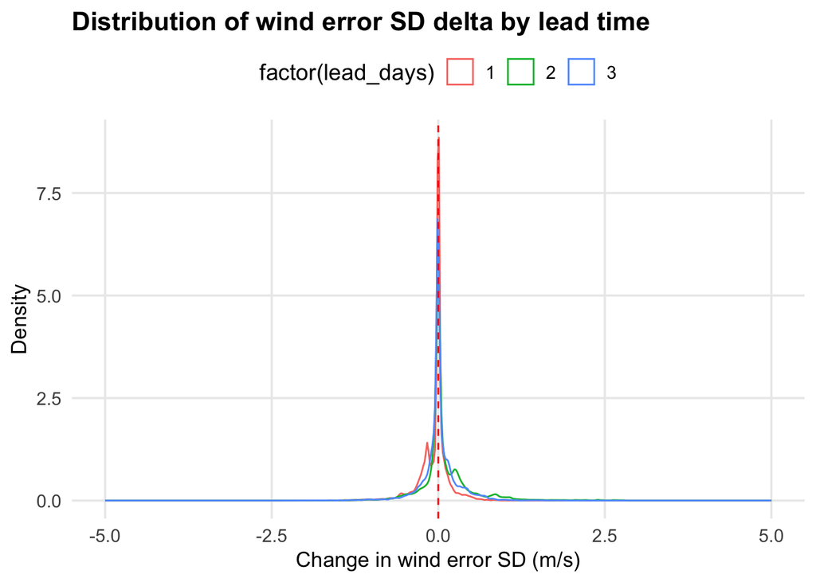

Calculate mean changes by lead day and t-test on difference from zero

| lead_days | 1.0000000 | 2.0000000 | 3.0000000 |
| --- | --- | --- | --- |
| mean_wind_error_all | -0.1597435 | -0.1496871 | 0.8442452 |
| mean_wind_error_no | -0.2459082 | -0.0076026 | 0.7666016 |
| mean_wind_error_delta | 0.0861647 | -0.1420845 | 0.0776436 |
| pval_wind_error_delta | 0.0000000 | 0.0000000 | 0.0000000 |
| mean_wind_sd_all | 1.2146732 | 1.8215817 | 1.9508646 |
| mean_wind_sd_no | 1.2638600 | 1.7253687 | 1.9359434 |
| mean_wind_sd_delta | -0.0491868 | 0.0962130 | 0.0149212 |
| pval_wind_sd_delta | 0.0000000 | 0.0000000 | 0.0000000 |

So, augmented observations actually shift mean errors up with lead days 1 and 3, and SDs with 2 and 3 lead days. All differences are statistically significant, but the mean effects are really small, so no practical significance.

What about absolute and squared error changes?

| lead_days | 1.0000000 | 2.0000000 | 3.0000000 |
| --- | --- | --- | --- |
| mean_wind_error_abs_all | 1.0361299 | 1.4257614 | 1.8606954 |
| mean_wind_error_abs_no | 1.1031621 | 1.3456915 | 1.7220948 |
| mean_wind_error_delta_abs | -0.0670323 | 0.0800699 | 0.1386007 |
| pval_wind_error_delta_abs | 0.0000000 | 0.0000000 | 0.0000000 |
| mean_wind_error_sq_all | 3.8575633 | 7.1187024 | 13.3041929 |
| mean_wind_error_sq_no | 4.0431465 | 6.8301328 | 12.1038950 |
| mean_wind_error_delta_sq | -0.1855832 | 0.2885696 | 1.2002980 |
| pval_wind_error_delta_sq | 0.0000000 | 0.0000000 | 0.0000000 |

These above show that augmented observations actually increase the mean absolute error and squared error with 2 and 3 lead days.

But perhaps the massive number of observations with low wind speed is driving this. Let’s segment by Renato’s intensity grouping. This time, we focus only on absolute error and SD changes.

Since we have many values, let’s plot these with point ranges

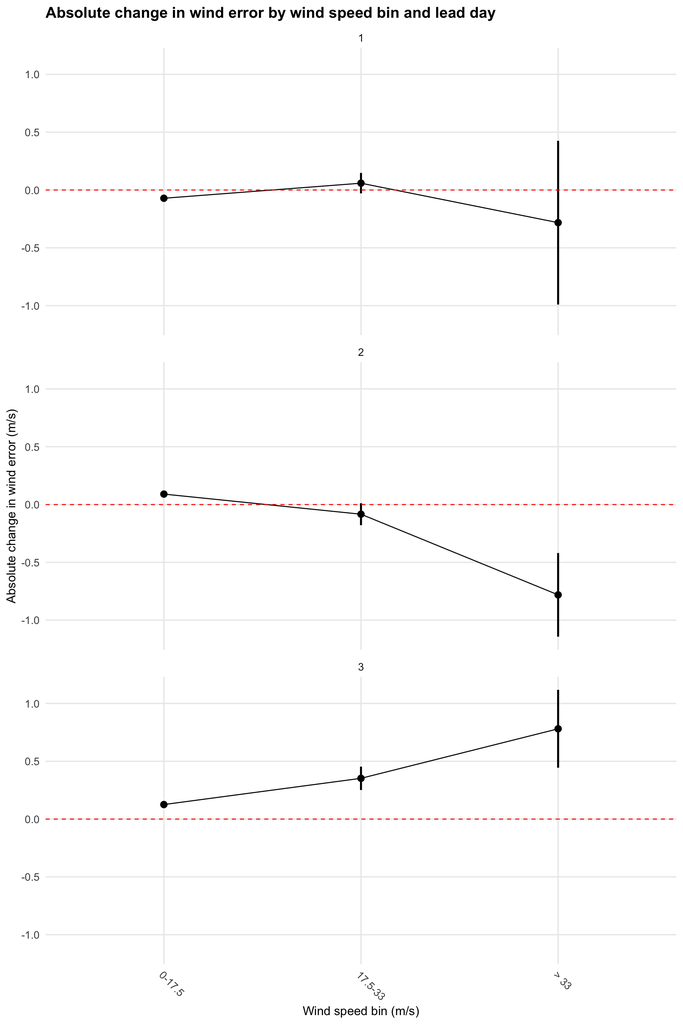

A small decrease in absolute errors for moderate and strong winds with 2 lead days. But a slighlty larger and imprecise increase in errors with 3 lead days.

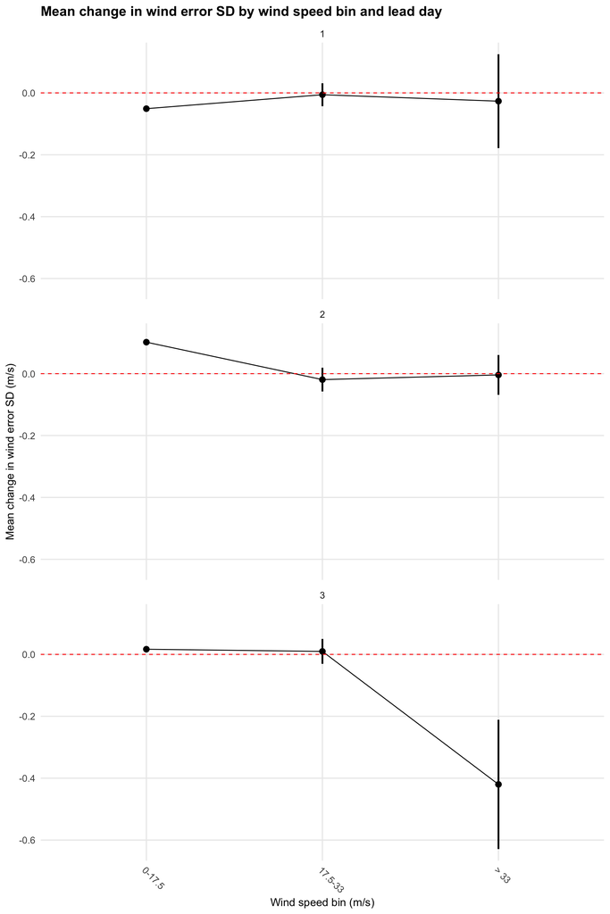

Not much action with SDs, except for strong winds with 3 lead days, which sees a tiny reduction.

Perhaps this binning is too coarse. Let’s try binning if further.

Plot again

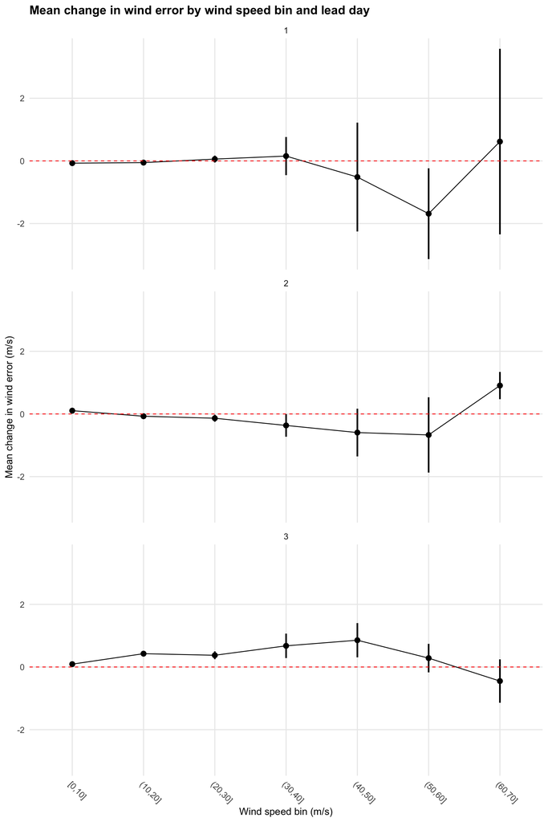

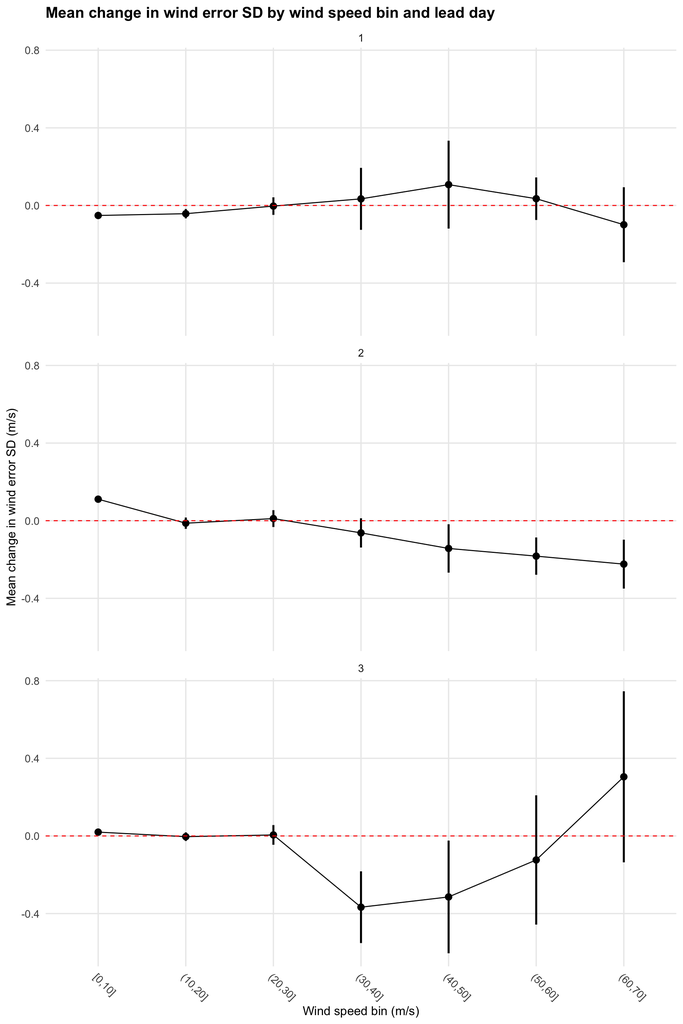

Not much more info on these…

Perhaps there are different patterns for different hurricanes. Let’s fcalculate and plot differences by hurricane.

Plot (with facet wrap by hurricane)

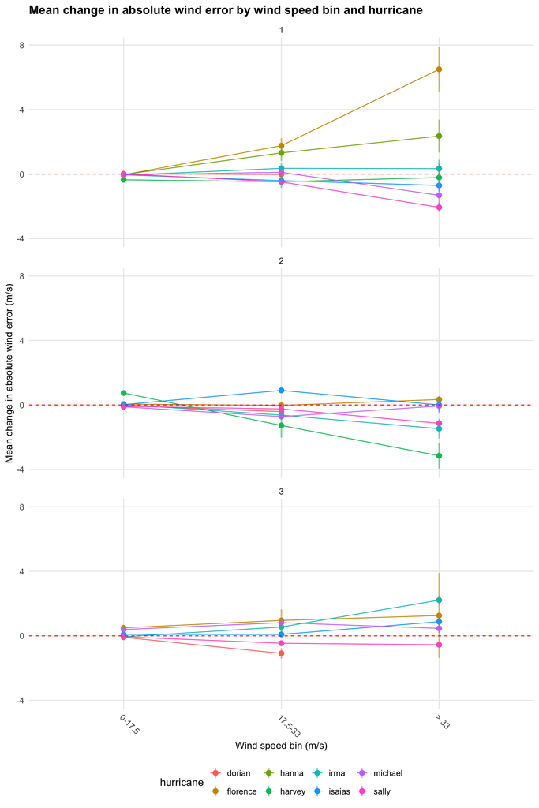

Sally seems to be the only case with consistent improvements.

OK, so the mean effects are not that informative. Even if differences exist and are statistically significant, they are very small even at high wind speeds.

### Unconditional quantile shifts

Compare CDFs of errors for each lead day (similar to Renato’s densities)

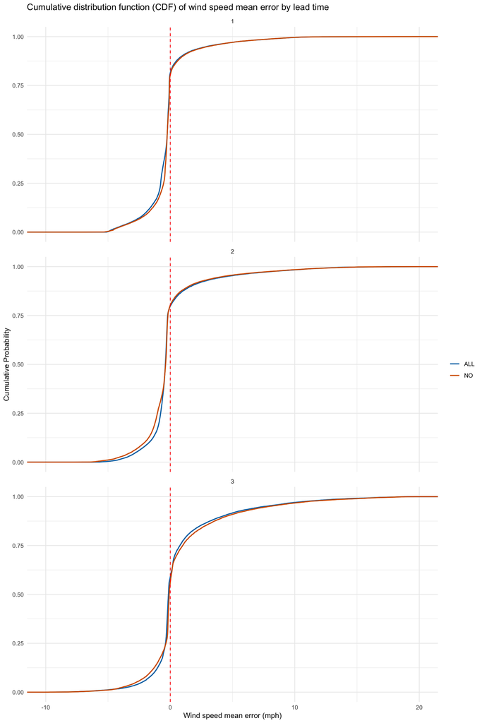

To make comparisons easier, make a Q-Q plot for each lead day

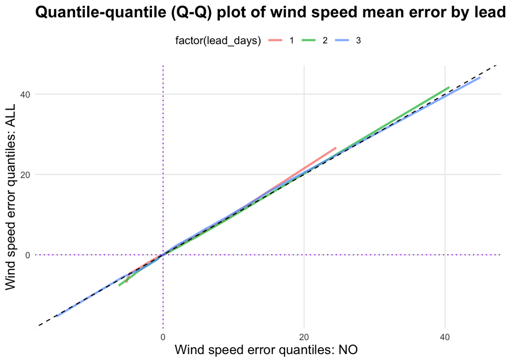

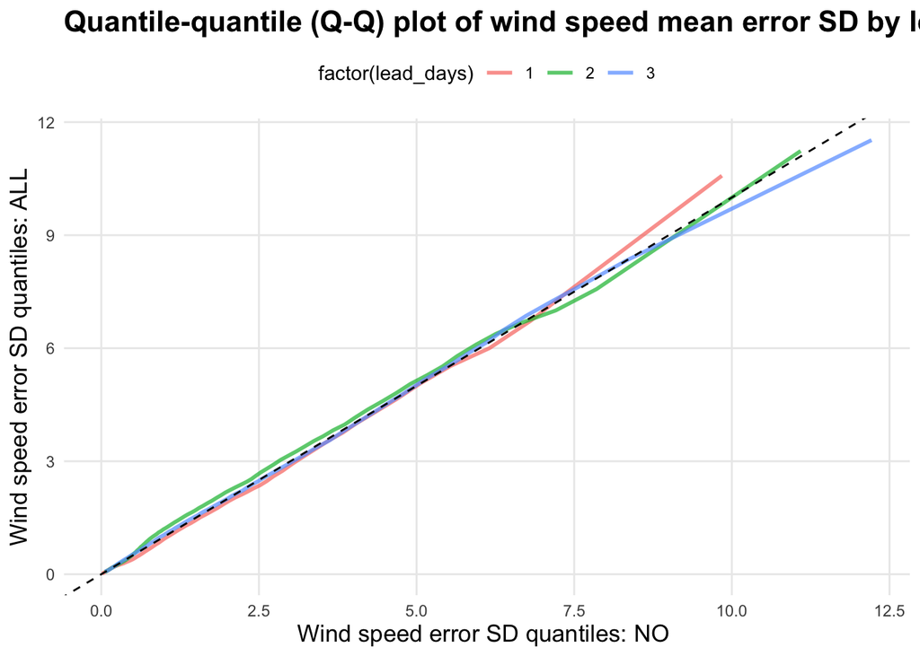

Make Q-Q plots by intensity bins

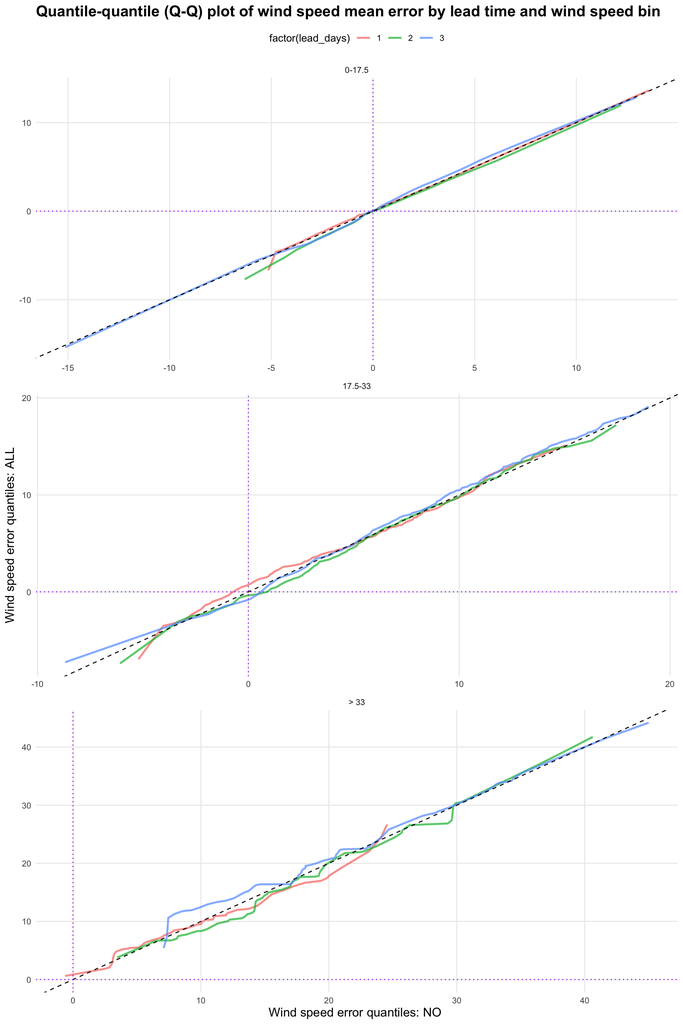

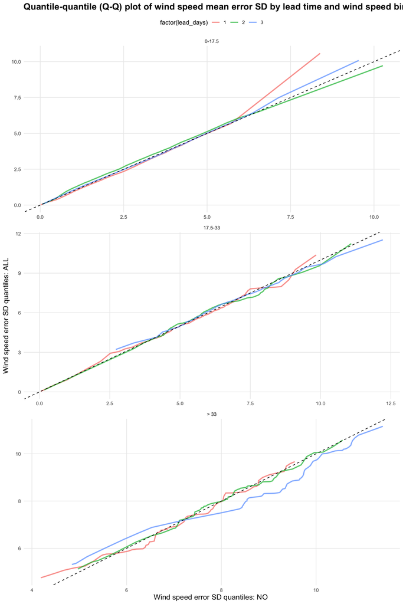

Very noisy.